# multi-level models - reading

2023-01-31

# 13. 1: Let’s look at multi-level models.

```r
library(rethinking)
library(tidyverse)
data(reedfrogs)
d <- tibble(reedfrogs)
d <- d %>%
  mutate(tank = 1:nrow(d))
```

Each row is a tank (so it seems like the rows in this case are aggregated data)  
- Multiple observations within ONE case = cluster  
- we want to measure the intercept for each cluster, and variation between clusters  
- vary intercepts -> varying effects -> use a unique intercept parameter for each cluster

## Let’s make a regular GLM for the tank example (page 402)

```r
dat <- d %>%
  mutate(S = surv) %>%
  mutate(N = density)

# approximate posterior
m13.1 <-ulam(
alist(
S ~ dbinom(N,p),
logit(p) <- a[tank],
a[tank] ~ dnorm(0,1.5)
), data = dat,chains = 4, log_lik = TRUE)
```

[output not shown]

[output not shown]

```r
precis(m13.1, 2)
```

```
##                mean        sd        5.5%       94.5%    n_eff     Rhat4
## a[1]   1.7058495587 0.7662409  0.58601385  2.96977585 4663.081 0.9993435
## a[2]   2.4141092701 0.8733617  1.14404170  3.89893005 3371.323 0.9995596
## a[3]   0.7609940060 0.6522345 -0.27511515  1.83476130 4688.668 0.9988267
## a[4]   2.3902299983 0.8784278  1.10185920  3.87024570 4298.773 0.9985415
## a[5]   1.7075106601 0.7867957  0.50084808  2.99144345 3996.418 0.9993333
## a[6]   1.7203072217 0.7657151  0.54331611  3.00127190 4006.071 0.9984823
## a[7]   2.4004654534 0.8635772  1.08021360  3.86858350 4312.873 0.9993977
## a[8]   1.7261531544 0.7744864  0.56308779  3.00650710 4744.267 0.9987293
## a[9]  -0.3780077520 0.6043686 -1.40079030  0.55242447 3730.994 0.9987811
## a[10]  1.7241383563 0.7871547  0.57634979  3.08321215 2905.298 1.0000625
## a[11]  0.7629924531 0.6557126 -0.23406957  1.85920575 5876.542 0.9986715
## a[12]  0.3610746961 0.6119098 -0.64093311  1.30330750 4836.038 0.9987084
## a[13]  0.7614487781 0.6641328 -0.25924024  1.86183230 3904.950 0.9990306
## a[14] -0.0006237456 0.5866221 -0.95275361  0.93177164 4744.994 0.9986493
## a[15]  1.7419800058 0.7757503  0.60016048  3.02124950 3958.056 0.9995108
## a[16]  1.7051137753 0.7474592  0.59482334  2.96528380 3876.799 0.9995442
## a[17]  2.5479227510 0.6659033  1.56921590  3.66349205 3996.093 0.9985148
## a[18]  2.1434539010 0.5950430  1.26844075  3.13028725 3949.692 0.9994166
## a[19]  1.8115526505 0.5368864  0.99441848  2.71163550 4931.287 0.9985419
## a[20]  3.0730157450 0.7752895  1.92693210  4.40583885 4716.700 0.9987904
## a[21]  2.1430192840 0.5764079  1.27305690  3.09913695 3682.580 0.9987478
## a[22]  2.1520038575 0.6006230  1.27044135  3.17123605 3540.396 0.9991861
## a[23]  2.1354117835 0.6312663  1.20429310  3.18337060 4192.291 0.9988508
## a[24]  1.5476270162 0.5000502  0.80066971  2.37844540 3904.672 0.9992142
## a[25] -1.0896152735 0.4474501 -1.82488640 -0.40245283 4954.630 0.9992775
## a[26]  0.0762710388 0.4176660 -0.59876415  0.74669418 4496.319 0.9987015
## a[27] -1.5515053266 0.5007569 -2.38640610 -0.79915598 4699.374 0.9987505
## a[28] -0.5489535468 0.4002270 -1.20859020  0.07277292 4143.210 0.9988355
## a[29]  0.0851620796 0.4001926 -0.55536964  0.74271917 5144.072 0.9993583
## a[30]  1.2908077612 0.4646511  0.58956237  2.05682460 4884.585 0.9984627
## a[31] -0.7265401369 0.4036429 -1.39367650 -0.08323898 4141.088 0.9990616
## a[32] -0.3883414786 0.3969399 -1.02508030  0.21570897 5321.411 0.9984914
## a[33]  2.8473631395 0.6536512  1.89965910  3.95329200 5155.027 0.9991473
## a[34]  2.4545239355 0.5728693  1.60473055  3.41539865 4614.643 0.9984000
## a[35]  2.4635903265 0.5681965  1.62707725  3.41398615 3582.776 0.9989577
## a[36]  1.9002200920 0.4637630  1.18928095  2.67973080 4688.478 1.0000178
## a[37]  1.9077022350 0.4809925  1.14799130  2.71749055 4206.762 0.9990635
## a[38]  3.3412684550 0.7520341  2.24121000  4.60395325 3756.599 0.9984840
## a[39]  2.4627458005 0.5893718  1.60881525  3.45398045 3439.307 0.9991134
## a[40]  2.1597439870 0.5415122  1.34518460  3.05777580 4811.331 0.9983524
## a[41] -1.9247210120 0.4844152 -2.72746970 -1.20868715 2849.750 0.9992351
## a[42] -0.6364543538 0.3528444 -1.20773220 -0.09029032 5412.441 0.9990495
## a[43] -0.5029452260 0.3396699 -1.05680300  0.03428270 3698.997 0.9992278
## a[44] -0.3907269759 0.3490048 -0.96955448  0.15222327 4323.852 0.9996504
## a[45]  0.5060108046 0.3468666 -0.03351087  1.06771935 5933.806 0.9987932
## a[46] -0.6318063105 0.3340463 -1.18064310 -0.10415388 4862.526 0.9985891
## a[47]  1.9157405885 0.4760212  1.20381560  2.69203255 3758.081 1.0000133
## a[48] -0.0538453499 0.3412224 -0.59468653  0.47345781 5727.869 0.9987558
```

- 48 different intercepts, one for each cluster (tank)
- To get each tank’s expected survival probability, just take one of the a values and then use the logistic transform

```r
# let's look at the interpretation of one of the intercepts

# compute by using equation to transform from log-odds to probability

exp(1.68) / (1 + exp(1.68))
```

```
## [1] 0.8429045
```

Tank 1’s expected survival probability is 0.84.

## multi-level model for tadpole example (page 403)

- the model will use adaptive pooling to gather information from *across* tanks.
- All that is required to enable adaptive pooling is to make the prior for the a parameters a function of some new parameters (almost like nesting)
  - hyper-parameters -> they are parameters for the parameters
  - hyper-priors -> they are priors of the hyper-parameters
- we have to use `ulam` for these models instead of `quap` (see page 403)

```r
m13.2  <- ulam(
alist(
S ~ dbinom(N,p),
logit(p) <- a[tank],
a[tank] ~ dnorm(a_bar, sigma),
# normal distribution describing distribution of tanks
# notice how the parameter from the equation now has its own hyper-parameter
a_bar ~ dnorm(0, 1.5), # hyper-parameter and hyper-priors
sigma ~ dexp(1)), data = dat, chains = 4, log_lik = TRUE)
```

[output not shown]

[output not shown]

```r
precis (m13.2, 2)
```

```
##              mean        sd         5.5%        94.5%    n_eff     Rhat4
## a[1]   2.13092132 0.8826591  0.789896500  3.567692050 2379.525 0.9996249
## a[2]   3.05935740 1.1182380  1.480666750  4.966995500 2276.453 0.9992694
## a[3]   1.00286328 0.6644302  0.007266823  2.092307400 2845.298 0.9985188
## a[4]   3.02801358 1.0936451  1.480632200  4.919518700 2132.892 1.0004145
## a[5]   2.11393094 0.8635731  0.863828910  3.566288700 2576.719 0.9998849
## a[6]   2.14517898 0.8841507  0.834913940  3.710752800 3239.975 1.0001525
## a[7]   3.04908036 1.0866398  1.527275650  4.931582050 2324.592 0.9998458
## a[8]   2.11061523 0.8670156  0.851027385  3.622795250 2247.348 0.9990192
## a[9]  -0.15583802 0.6490455 -1.200479450  0.872775130 4393.128 0.9983678
## a[10]  2.12099616 0.8790669  0.849006865  3.632461550 2889.865 0.9985600
## a[11]  0.98091567 0.6753249 -0.027518572  2.100054800 2910.287 1.0004887
## a[12]  0.57621125 0.6164588 -0.367536075  1.566258300 3959.396 0.9995538
## a[13]  0.98824231 0.7085728 -0.123389130  2.109664450 3141.101 0.9987945
## a[14]  0.20261754 0.6085893 -0.756263550  1.165020650 3156.132 0.9994002
## a[15]  2.16360793 0.9059948  0.838356490  3.717707700 2482.968 1.0000504
## a[16]  2.11950815 0.8401568  0.890174445  3.562033750 3524.874 0.9991531
## a[17]  2.90054383 0.7888350  1.788198900  4.286869900 2659.141 0.9987902
## a[18]  2.39789272 0.6860113  1.407003050  3.582675150 2794.595 0.9992989
## a[19]  2.02772411 0.5772598  1.177696350  3.013715550 2901.531 0.9995409
## a[20]  3.65736363 0.9742695  2.218773300  5.312682350 2319.355 1.0004019
## a[21]  2.37974915 0.6186043  1.480307300  3.455760600 2696.790 0.9986848
## a[22]  2.37455509 0.6345389  1.434144800  3.448515450 3438.301 1.0007522
## a[23]  2.38973479 0.6907773  1.353418800  3.584797750 3261.887 0.9987933
## a[24]  1.68585503 0.5404559  0.854897950  2.572433900 3384.523 0.9996975
## a[25] -1.00295747 0.4377527 -1.708972600 -0.336526070 3470.797 0.9995611
## a[26]  0.16214137 0.3994732 -0.463314210  0.784725605 3585.376 0.9989855
## a[27] -1.43170284 0.4836855 -2.216255400 -0.718291410 2321.246 0.9989137
## a[28] -0.45885201 0.3918341 -1.094191900  0.151779610 3718.920 0.9995312
## a[29]  0.16595287 0.3899073 -0.456165805  0.781340810 4172.963 0.9983636
## a[30]  1.42218129 0.4879895  0.700185610  2.262925000 3133.313 0.9986428
## a[31] -0.64439864 0.4105617 -1.322539900  0.004756092 3207.018 0.9997976
## a[32] -0.29804277 0.4121077 -0.962445990  0.367207665 4779.762 0.9992902
## a[33]  3.15458186 0.7110788  2.111936900  4.332062200 2782.613 0.9992501
## a[34]  2.69854722 0.6337565  1.759529950  3.735259600 2296.086 1.0006581
## a[35]  2.70148025 0.6304909  1.777885050  3.799001300 3285.466 0.9987325
## a[36]  2.06540998 0.4909624  1.338466400  2.900100100 2583.662 1.0007264
## a[37]  2.06528784 0.5171246  1.290970150  2.934257400 3081.663 0.9989583
## a[38]  3.87869892 0.9477945  2.550079750  5.497457200 1985.561 1.0008485
## a[39]  2.70165946 0.6311327  1.777346700  3.795419950 3194.374 0.9989169
## a[40]  2.35130833 0.5612075  1.516976100  3.324248950 2950.986 0.9993586
## a[41] -1.80057682 0.4676018 -2.586495500 -1.107434500 3296.144 0.9993821
## a[42] -0.56070289 0.3518131 -1.127832500 -0.008425756 3789.696 0.9983711
## a[43] -0.45033129 0.3244844 -0.971150870  0.055712967 3562.593 0.9985227
## a[44] -0.34121302 0.3314590 -0.870933715  0.179213205 3864.347 0.9990719
## a[45]  0.57726284 0.3522901  0.025861596  1.163328000 3804.890 0.9992260
## a[46] -0.57220541 0.3567955 -1.146083450  0.013905442 3013.838 1.0001021
## a[47]  2.05213167 0.5001322  1.284840550  2.879218300 3048.508 0.9992094
## a[48]  0.00359739 0.3462087 -0.542591775  0.570504685 3485.362 0.9989064
## a_bar  1.34114584 0.2531240  0.944386685  1.757748500 2479.948 0.9997325
## sigma  1.60873930 0.2085294  1.305124050  1.961439800 1453.135 0.9992348
```

- This model provides posterior distributions for 50 parameters: one overall sample intercept (a-bar), the standard deviation among tanks (sigma), and then 48 per-tank intercepts.

## Let’s do some model comparison

```r
compare( m13.1,m13.2)
```

```
##           WAIC       SE    dWAIC      dSE    pWAIC      weight
## m13.2 199.4960 7.345552  0.00000       NA 20.62496 0.999051839
## m13.1 213.4161 4.597961 13.92008 3.896713 24.91583 0.000948161
```

notice the pWAIC -> this is the number of effective parameters (sounds like it means the number of parameters that allow the model to make predictions?)

### NEW PRIOR ALERT: **half-normal distribution** (overthinking pg. 408)

A half-Normal distribution is a normal distribution with all mass above zero.

```r
# change prior to half normal... not sure why?
m13.2a  <- ulam(
alist(
S ~ dbinom(N,p),
logit(p) <- a[tank],
a[tank] ~ dnorm(a_bar, sigma),
a_bar ~ dnorm(0, 1.5),
sigma ~ dhalfnorm(0,1)), # using half-normal prior
data = dat, chains = 4, log_lik = TRUE)
```

[output not shown]

[output not shown]

```r
# model comparison

compare( m13.1,m13.2, m13.2a)
```

```
##            WAIC       SE        dWAIC      dSE    pWAIC       weight
## m13.2a 199.4912 7.028809  0.000000000       NA 20.60997 0.5003660219
## m13.2  199.4960 7.345552  0.004825397 1.261570 20.62496 0.4991602447
## m13.1  213.4161 4.597961 13.924900603 3.450878 24.91583 0.0004737335
```

# 13.2: pooling data, over-fitting and under-fitting

- now the tanks are ponds…
  1. complete pooling: assuming all ponds are the same (no variation)
     - ignore varying intercepts, use the overall mean across ponds
     - estimate of the intercept is unlikely to match any of the ponds
     - THIS IS UNDER-FITTING
  2. no pooling: assume that each pond tells us nothing about the others (infinite variation)
     - now we just use the outcome from each pond to predict
     - small amount of data went into each cluster outcome variable
     - high error for these estimates
     - THIS IS OVER-FITTING
  3. partial pooling: adaptive regularizing priors
     - produces estimates for each cluster that are less under-fit than grand mean and less over-fit than the no-pooling estimates
     - tend to be better estimates of the TRUE per-cluster (per-pond) means
       - especially for clusters with less information

## Simulating and validating models

basically, we. are going to simulate all the values for the model

$$S_i \sim Binomial(N_i,p_i)\\
logit(p_i) = \alpha_{POND[i]}\\
\alpha_j \sim Normal(\bar\alpha, \sigma)\\
\bar \alpha \sim Normal(0,1.5)\\
\sigma \sim Exponential(1)$$

**What do each of the parameters mean?** $\bar \alpha$, the average log-odds of survival in the entire population of ponds  
$\sigma$, the standard deviation of the distribution of log-odds of survival among ponds  
$\alpha$, a vector of individual pond intercepts, one for each pond

### Assign values to your parameters

- our priors are not apart of our model now (in simulation)

```r
a_bar <-1.5 # chosen mean value for pop
sigma <-1.5 # chosen deviation for pop
nponds <- 60 #simulating 60 ponds (cases)
Ni <-as.integer(rep(c(5,10,25,35),each=15))
# different densities (input, 15 5s, 15 10s, 15 25s, 15 35s = 60)
```

`a_bar` and `sigma` define a Gaussian distribution of individual pond log-odds survival

now we need to simulate with this distribution but across our 60 ponds.

```r
set.seed(5005)
a_pond <- rnorm(nponds,mean = a_bar, sd = sigma)
# log odds of survival for each pond


# let's put the information into a tibble
dsim <- tibble(a_pond) %>%
  mutate(true_a = a_pond) %>% # output, survival simulate
  mutate(pond = 1:nponds) %>% # pond index
  mutate(Ni = Ni) %>% # simulated initial tadpole count
  select(pond, Ni, true_a)
```

### Simulate surivors (outcome)

```r
dsim <- dsim %>%
  mutate( Si = rbinom(nponds,prob=logistic(dsim$true_a),size=dsim$Ni))
```

### compute no-pooling estimates

- basically, we are going to calculate the survival proportions

```r
dsim <- dsim %>%
  mutate(p_nopool = Si/Ni)
```

### calculating partial-pooling estimates

#### step one: for this, we actually have to utilize the model

```r
m13.3 <-ulam(
alist(
Si ~ dbinom(Ni, p),
logit(p) <- a_pond[pond],
a_pond[pond] ~ dnorm(a_bar, sigma),
a_bar ~ dnorm(0,1.5),
sigma ~ dexp(1)
), data = dsim, chains = 4)
```

[output not shown]

```r
precis( m13.3,depth=2)
```

```
##                   mean        sd         5.5%       94.5%     n_eff     Rhat4
## a_pond[1]   1.65730776 0.9745453  0.201252160  3.27100870 3009.9039 0.9998850
## a_pond[2]   2.86703985 1.2559383  1.030634900  4.95785025 2656.9796 0.9986684
## a_pond[3]  -0.62607263 0.8876126 -2.064297800  0.77188517 3051.3731 0.9985318
## a_pond[4]   2.85035863 1.3040527  1.018978850  5.12024365 2414.8921 0.9998226
## a_pond[5]   2.87630741 1.2506420  1.097145750  5.09450750 2642.6157 0.9990290
## a_pond[6]   2.90207159 1.2838338  1.019692500  5.14233980 2760.2969 0.9992278
## a_pond[7]   0.06393675 0.8595913 -1.284465000  1.48376450 4323.5061 0.9993655
## a_pond[8]   2.87398214 1.2411903  1.073352700  4.98954010 2344.2285 1.0000118
## a_pond[9]   1.64409263 0.9657575  0.195295200  3.23680570 3966.5653 0.9985179
## a_pond[10]  1.64254841 0.9688537  0.228070735  3.25201745 3743.1416 0.9987094
## a_pond[11]  2.88875978 1.2461074  1.072577900  4.96329430 2819.9938 0.9982797
## a_pond[12]  0.07336768 0.8105963 -1.219040850  1.38032730 3149.0683 0.9983443
## a_pond[13]  2.89854187 1.2118160  1.136992700  4.93434675 2188.3193 1.0003681
## a_pond[14]  2.94346286 1.2869278  1.015453450  5.10677555 2533.8313 0.9995731
## a_pond[15]  2.90593974 1.3055830  1.003257010  5.16440400 2412.6241 0.9990316
## a_pond[16]  1.54143607 0.7465000  0.425418940  2.81312890 3388.3003 0.9985171
## a_pond[17] -1.45545659 0.7540859 -2.695694100 -0.33399088 2979.6478 0.9992124
## a_pond[18]  1.05199577 0.6726160  0.021492576  2.13285605 2662.5777 0.9993167
## a_pond[19] -0.96298850 0.6867935 -2.082749550  0.08665525 3222.2324 0.9992639
## a_pond[20]  1.57493975 0.7769562  0.403998575  2.87925715 3257.0255 0.9987813
## a_pond[21] -0.16099563 0.6413534 -1.181615350  0.88606207 3808.9311 0.9986362
## a_pond[22]  2.24010919 0.8891423  0.969860450  3.80426850 2299.8498 0.9998194
## a_pond[23]  3.29049475 1.1954739  1.631088800  5.32102660 2082.4874 0.9996786
## a_pond[24]  0.62955963 0.6387227 -0.352021475  1.68372860 4160.3502 0.9984459
## a_pond[25]  3.33013926 1.2488628  1.576036000  5.56668235 2066.2008 0.9991076
## a_pond[26]  2.22088141 0.8992856  0.913602075  3.71682045 2151.6274 0.9991208
## a_pond[27]  1.03998078 0.6822058  0.021229122  2.20930325 3422.2915 0.9999433
## a_pond[28]  2.26729063 0.9412442  0.862177390  3.84119220 2984.8692 0.9988029
## a_pond[29]  1.55819861 0.7796299  0.420464775  2.88243630 3370.9204 0.9983517
## a_pond[30]  1.04900712 0.7086355 -0.019144689  2.20236165 4370.5934 0.9989570
## a_pond[31]  2.47245169 0.6813863  1.473502750  3.64834365 2318.4192 0.9991641
## a_pond[32]  2.06283885 0.5978031  1.155709500  3.10160835 4004.1876 0.9983323
## a_pond[33]  1.73551824 0.5295806  0.961135065  2.60581765 3671.1247 0.9983591
## a_pond[34]  1.22928256 0.4676366  0.531723380  1.97349045 3778.2549 0.9996864
## a_pond[35]  0.66227078 0.4066611  0.016384847  1.32541150 4021.0513 0.9983390
## a_pond[36]  3.85784559 1.0603348  2.337446650  5.62564790 2096.9523 0.9985553
## a_pond[37] -0.98248900 0.4411638 -1.707800400 -0.28916131 4062.2472 0.9985993
## a_pond[38] -1.19900772 0.4700970 -1.962638550 -0.45766247 3262.2187 0.9989197
## a_pond[39]  0.66155266 0.4224491  0.006307771  1.34842310 3603.7847 1.0008738
```

[output cut: 8 more lines]

```
## a_pond[48]  2.09133589 0.5232940  1.313494250  2.96158610 3186.7796 0.9990081
## a_pond[49]  1.85157008 0.4629154  1.147590100  2.63902100 3586.3477 0.9989402
## a_pond[50]  2.78800395 0.6650856  1.812165950  3.88472220 3393.6344 0.9982092
## a_pond[51]  2.39233446 0.5867639  1.515380500  3.38796920 2842.0732 0.9989321
## a_pond[52]  0.34977172 0.3526107 -0.197520245  0.93639771 3450.2220 0.9992001
## a_pond[53]  2.10732302 0.5295674  1.316830200  2.98973040 2833.4047 0.9996584
## a_pond[54]  4.07488231 1.0261993  2.619756350  5.84463260 2264.5793 1.0007858
## a_pond[55]  1.11760486 0.3740621  0.538305485  1.72930105 3299.3011 0.9983637
## a_pond[56]  2.81104508 0.7135291  1.803629000  3.96876220 1959.9856 1.0017737
## a_pond[57]  0.71149786 0.3623652  0.145665240  1.29740535 4681.1030 0.9983730
## a_pond[58]  4.08791003 1.0306799  2.645725450  5.87441830 1967.2050 0.9994080
## a_pond[59]  1.64190305 0.4492388  0.972884845  2.35699905 3307.9482 0.9994318
## a_pond[60]  2.39205268 0.5644498  1.563706900  3.34731195 3098.2550 0.9988148
## a_bar       1.66520087 0.2471732  1.276258550  2.07124715 1518.4289 1.0000504
## sigma       1.68123950 0.2301559  1.339822850  2.07253055  803.6766 0.9993145
```

#### step two: let’s predict survival proportions withe partial pool

```r
# get samples first, because now working witht the posterior
post <-extract.samples(m13.3)

# transform the proportions with inv_logit from the samples
dsim <- dsim %>%
  mutate(p_partpool = apply(inv_logit(post$a_pond), 2, mean))
```

#### step three: if you want to compare the survival proportions from the model to the the true per-pond probabilities do the following

```r
dsim <- dsim %>%
  mutate(p_true = inv_logit(true_a))
```

#### step four: compute the absolute error between the the estimates and thet true varying effects

```r
nopool_error <- abs(dsim$p_nopool - dsim$p_true)
partpool_error <- abs(dsim$p_partpool- dsim$p_true)
```

#### step five: plot the results (the code for the plot sucks but book example on 413 is nice, would be nice to get some help with tidy code)

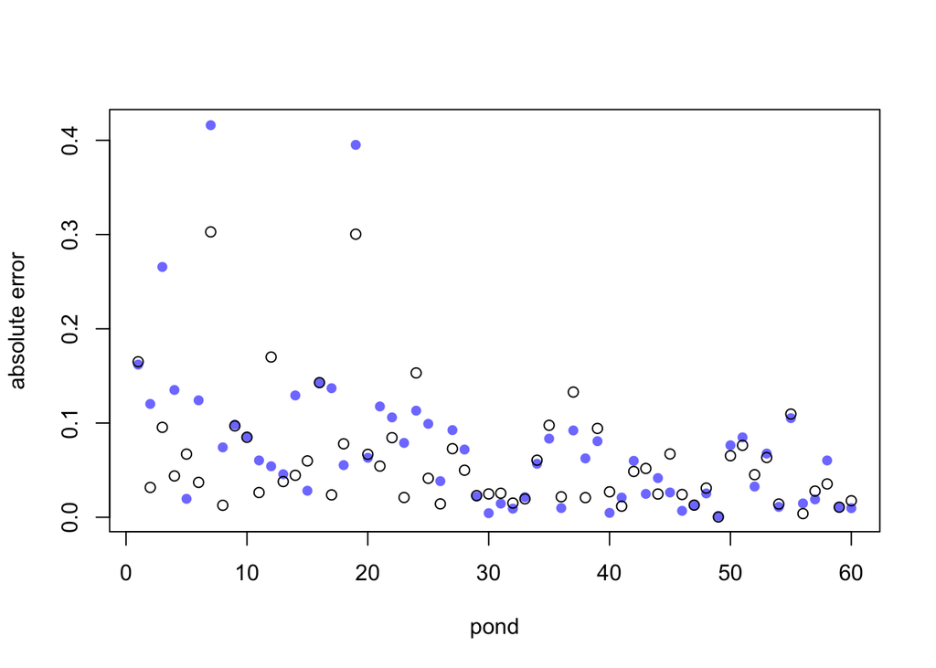

```r
plot(1:60, nopool_error, xlab = "pond", ylab="absolute error",
col = rangi2, pch = 16)
points(1:60, partpool_error)
```

- last information about pooling based on the example:\ - both kinds of estimates are much more accurate for larger ponds (right side); this arises because more data means better. estimates (assuming no confounding)  
- the no-pool estimates (shown by the blue points) have a higher average error in each group of ponds, except the medium ponds, partial pooling isn’t always better  
- **while both kinds of estimates suffer from reduced sample size, the partial pooling estimates suffer less**  
what about shrinkage?  
- the ponds with the smallest sample size show the greatest improvement over the no-pooling estimates  
- shrinkage towards the mean results from trying to negotiate the under-fitting and over-fitting risks of the grand mean on one end adn the individual means of each pond on the other  
- the larger ponds shrink much less, because they contain more information and are prone to less over-fitting (they need less correcting)  
- there are some cases where no-pooling estimates are better -> often for the ponds with extreme probabilities of survival

# 13.3: multiple types of clusters

- we’re going to use the chimpanzee data now. there are 2 types of clusters: the clusters for each individual chimp and the experimental blocks for observations on the same day

```r
# load data
library(rethinking)
data(chimpanzees)
d <- tibble(chimpanzees)

# transform data, and select only things needed for the model
d <- d %>%
  mutate(treatment = 1 + prosoc_left + 2 * condition) %>%
  mutate(block_id = block) %>%
  mutate(treatment = as.integer(treatment)) %>%
  select(pulled_left, actor, block_id, treatment)

set.seed(13)
# create the model
m13.4 <- ulam(
alist(
pulled_left ~ dbinom(1,p),
logit(p) <- a[actor] + g[block_id] + b[treatment],
b[treatment] ~ dnorm(0, 0.5),
  # adaptive priors below
a[actor] ~ dnorm(a_bar, sigma_a),
g[block_id] ~ dnorm(0, sigma_g),
  ## hyper-priors
a_bar ~ dnorm(0,1.5),
sigma_a ~ dexp(1),
sigma_g ~ dexp(1)) , data = d, chains = 4, cores = 4, log_lik = TRUE)
```

[output not shown]

```r
precis(m13.4, 2)
```

```
##                 mean        sd         5.5%       94.5%     n_eff     Rhat4
## b[1]    -0.131005514 0.3015011 -0.605322690  0.34940934  610.2244 1.0041123
## b[2]     0.405009429 0.3035400 -0.073329930  0.90068681  619.7941 1.0016464
## b[3]    -0.470428520 0.3049855 -0.958576045  0.00261029  589.8346 1.0032233
## b[4]     0.280501020 0.3011763 -0.188790225  0.75564694  607.2497 1.0041857
## a[1]    -0.367589261 0.3596180 -0.941542995  0.22455135  572.0095 1.0037565
## a[2]     4.620008805 1.2863160  3.026051850  6.78534185  720.4670 1.0023716
## a[3]    -0.671717827 0.3703038 -1.284155300 -0.07930272  626.9429 1.0044333
## a[4]    -0.665175230 0.3644561 -1.277798050 -0.10900505  623.3603 1.0030791
## a[5]    -0.360023078 0.3656518 -0.947495035  0.21199991  677.9544 1.0018323
## a[6]     0.576127607 0.3671682 -0.002665405  1.17527890  561.3093 1.0045842
## a[7]     2.106764151 0.4686412  1.389680200  2.87967260  700.1257 1.0040178
## g[1]    -0.185702192 0.2178343 -0.586706970  0.07108232  680.4218 1.0059754
## g[2]     0.037852920 0.1811201 -0.230221610  0.34788747 1277.4377 0.9989643
## g[3]     0.055786502 0.1819976 -0.200693390  0.36817323 1054.3381 1.0003744
## g[4]     0.004709123 0.1838587 -0.293344065  0.30117936 1353.6755 1.0007138
## g[5]    -0.028278152 0.1747931 -0.313453520  0.24118645 1221.0113 1.0003955
## g[6]     0.120776610 0.1979242 -0.137575530  0.47542285 1120.4761 1.0019107
## a_bar    0.573198885 0.7198712 -0.561036405  1.71235125  965.8428 1.0048848
## sigma_a  1.997930130 0.6237053  1.229373750  3.08411280  905.6512 1.0028455
## sigma_g  0.225482193 0.1748964  0.035561201  0.50142372  440.4279 1.0123727
```

Let’s look at a model that only varies the intercepts of the actors (7 chimps) and ignores the block variable.

```r
set.seed(14)

# model without block
m13.5 <- ulam(
alist(
pulled_left ~ dbinom(1,p),
logit(p) <- a[actor] + b[treatment],
b[treatment] ~ dnorm(0,0.5),
a[actor] ~ dnorm(a_bar,sigma_a),
a_bar ~ dnorm(0,1.5),
sigma_a ~ dexp(1)
), data = d, chains = 4, cores = 4, log_lik = TRUE)
```

[output not shown]

```r
precis(m13.5, 2)
```

```
##               mean        sd        5.5%        94.5%     n_eff     Rhat4
## b[1]    -0.1306825 0.2917299 -0.61761137  0.317898000  689.0899 1.0014772
## b[2]     0.4005796 0.2898843 -0.05925513  0.859598175  742.1318 1.0025769
## b[3]    -0.4680841 0.2935358 -0.93334089  0.003777738  691.8163 1.0016905
## b[4]     0.2869411 0.2871938 -0.18368661  0.745722745  687.1568 1.0035372
## a[1]    -0.3550147 0.3277652 -0.87132530  0.165516570  768.4753 1.0003174
## a[2]     4.5989149 1.2481315  3.00012895  6.799107550  875.8020 1.0032904
## a[3]    -0.6666458 0.3565955 -1.23951520 -0.121957965  792.9090 1.0036632
## a[4]    -0.6553838 0.3420910 -1.18544980 -0.106543735  854.2939 1.0012035
## a[5]    -0.3599562 0.3503534 -0.91893457  0.173923980  764.3856 1.0018226
## a[6]     0.5715198 0.3363214  0.04980759  1.119492200  740.7167 1.0021703
## a[7]     2.0897025 0.4351310  1.39623995  2.803790100  885.3282 1.0015599
## a_bar    0.5617224 0.7269571 -0.58446942  1.695808850 1178.5556 0.9985497
## sigma_a  1.9862722 0.6466686  1.19128715  3.074831650 1077.2665 0.9996687
```

```r
# compare
compare(m13.5, m13.4)
```

```
##           WAIC       SE     dWAIC      dSE     pWAIC    weight
## m13.5 531.5537 19.15349 0.0000000       NA  8.701194 0.5881438
## m13.4 532.2663 19.38305 0.7125941 1.821363 10.732596 0.4118562
```

- relationship between shrinkage andd predicted variation -> the estimated variation across actors is much larger, meaning less shrinkage : LARGER VARIATION = LESS SHRINKAGE TOWARDS THE POP MEAN
- can we use partial pooling on the treatment variable (the thing we controlled within the experiment)?  
  Yes, if the index values could be reassigned without changing the meaning of the model, then partial pooling could help

Here is the model for each treatment, since each treatment (cluster) has a lot of data within each, partial pooling won’t really help.

```r
set.seed(15)

m13.6 <-ulam(
alist(
pulled_left ~ dbinom(1,p),
logit(p) <- a[actor] + g[block_id] + b[treatment],
b[treatment] ~ dnorm(0,sigma_b),
a[actor] ~ dnorm(a_bar,sigma_a),
g[block_id] ~ dnorm(0,sigma_g),
a_bar ~ dnorm(0,1.5),
sigma_a ~ dexp(1),
sigma_g ~ dexp(1),
sigma_b ~ dexp(1)
), data = d, chains = 4, cores = 4, log_lik = TRUE)
```

[output not shown]

```r
# compare coefficients for each model
coeftab( m13.4, m13.6)
```

```
##         m13.4   m13.6
## b[1]      -0.13   -0.10
## b[2]       0.41    0.41
## b[3]      -0.47   -0.42
## b[4]       0.28    0.29
## a[1]      -0.37   -0.39
## a[2]       4.62    4.60
## a[3]      -0.67   -0.69
## a[4]      -0.67   -0.68
## a[5]      -0.36   -0.39
## a[6]       0.58    0.55
## a[7]       2.11    2.08
## g[1]      -0.19   -0.18
## g[2]       0.04    0.05
## g[3]       0.06    0.06
## g[4]       0.00    0.01
## g[5]      -0.03   -0.04
## g[6]       0.12    0.13
## a_bar      0.57    0.58
## sigma_a    2.00    1.97
## sigma_g    0.23    0.23
## p[1]       0.34    0.34
## p[2]       0.34    0.34
## p[3]       0.46    0.46
## p[4]       0.34    0.34
## p[5]       0.46    0.46
## p[6]       0.46    0.46
## p[7]       0.52    0.52
## p[8]       0.52    0.52
## p[9]       0.39    0.40
## p[10]      0.39    0.40
## p[11]      0.39    0.40
## p[12]      0.52    0.52
## p[13]      0.39    0.40
## p[14]      0.52    0.52
## p[15]      0.39    0.40
## p[16]      0.52    0.52
## p[17]      0.52    0.52
## p[18]      0.39    0.40
## p[19]      0.51    0.51
```

[output cut: 472 more lines]

```
## p[492]     0.83    0.83
## p[493]     0.91    0.91
## p[494]     0.82    0.83
## p[495]     0.82    0.83
## p[496]     0.91    0.91
## p[497]     0.91    0.91
## p[498]     0.91    0.91
## p[499]     0.92    0.92
## p[500]     0.92    0.92
## p[501]     0.92    0.92
## p[502]     0.84    0.85
## p[503]     0.84    0.85
## p[504]     0.84    0.85
## sigma_b      NA    0.58
## nobs        504     504
```

# 13.4: divergent transitions and non-centered priors

**what are divergent transitions?**  
- when posterior distribution is very steep in some region of a parameter’s space, the energy used in the model is sometimes different from start and end.

**how do we fix?**  
- reparameterize -> for any given statistical model, it can be written in several forms that are mathematically identical but numerically different.

### example number one: centered vs. non centered parameters

```r
m13.7 <- ulam(
alist(
v ~ normal(0, 3),
x ~ normal(0, exp(v))
), data = list(N = 1), chains = 4)
```

[output not shown]

```r
precis( m13.7)
```

```
##        mean         sd        5.5%      94.5%    n_eff    Rhat4
## x -20.38538 730.034895 -434.214475 108.489605 34.11960 1.150758
```

At low values of v, the distribution of x contracts around o, this forms a steep valley (think of the end of a funnel) that the Hamiltonian particle needs to explore.

MAIN IDEA = DIVEGENT TRANSITIONS MEANS THAT WHEN YOU SAMPLE FROM THE DISTRIBUTION YOU WILL HAVE A VERY UNRELIABLE APPROXIMATION OF THE POSTERIOR DISTRIBUTION

the source of the funneling is the description we gave to x  
$ x Normal(0,exp(v))$.

As v changes, the distribution of x changes in a very inconvenient way.

This is known as the **centered parameterization** -> indicates that the distribution of x is conditional on one or more other parameters

**non-centered parameterization** -> moves the embedded parameter (v in this case), out of the defintiion of the other parameter

$$v \sim Normal(0,3)\\
z \sim Normal(0,1)\\
x = z * exp(v)\\$$

```r
# here is how we do this in code

m13.7nc <-ulam(
alist(
v ~ normal(0, 3),
z ~ normal(0, 1),
gq > real[1]: x <<- z*exp(v) # standardizing x witih added z
), data = list(N=1),chains = 4)
```

[output not shown]

```r
precis(m13.7nc)
```

```
##          mean          sd       5.5%     94.5%    n_eff     Rhat4
## v -0.02392348   3.0225480  -4.896795  4.864587 1406.290 1.0021972
## z -0.02531352   0.9833841  -1.586140  1.610032 1609.676 0.9998362
## x 10.83483680 472.3895799 -18.620991 30.986968 1388.530 0.9985671
```

### example number 2: chimpanzees

- before reparameterizing, the first thing you can try is to increase the target acceptance rate `adapt_delta`.

When `adapt_delta` is set high, it results in smaller step size which means more accurate approximation

```r
# let's run the model with a higher target acceptance rate
set.seed(13)
m13.4b <- ulam(m13.4,chains = 4, cores = 4, control = list(adapt_delta = 0.99))
```

[output not shown]

```r
# look at the divergent transitions
divergent(m13.4b)
```

```
## [1] 1
```

```r
divergent(m13.4)
```

```
## [1] 2
```

**see notes in notebook on a better way to uncenter in reality with a multi-level model**

- the vector z gives the standardized intercept for each actor and the vector x gives the standardized intercept for each block.

```r
set.seed(13)
m13.4nc <-ulam(
alist(
pulled_left ~ dbinom(1, p),
# link function
logit(p) <- a_bar + z[actor] * sigma_a + #actorintercepts
x[block_id] * sigma_g + #blockintercepts
b[treatment] ,
  #parameters
b[treatment] ~ dnorm(0, 0.5),
z[actor] ~ dnorm(0, 1),
x[block_id] ~ dnorm(0, 1),
a_bar ~ dnorm(0, 1.5),
sigma_a ~ dexp(1),
sigma_g ~ dexp(1),
# notice, before we would have used a and g,
# but they have been redefined with x and z
gq> vector[actor]:a <<- a_bar + z * sigma_a,
gq> vector[block_id]:g <<- x * sigma_g
), data = d, chains = 4, cores = 4)
```

[output not shown]

```r
precis(m13.4, 2)
```

```
##                 mean        sd         5.5%       94.5%     n_eff     Rhat4
## b[1]    -0.131005514 0.3015011 -0.605322690  0.34940934  610.2244 1.0041123
## b[2]     0.405009429 0.3035400 -0.073329930  0.90068681  619.7941 1.0016464
## b[3]    -0.470428520 0.3049855 -0.958576045  0.00261029  589.8346 1.0032233
## b[4]     0.280501020 0.3011763 -0.188790225  0.75564694  607.2497 1.0041857
## a[1]    -0.367589261 0.3596180 -0.941542995  0.22455135  572.0095 1.0037565
## a[2]     4.620008805 1.2863160  3.026051850  6.78534185  720.4670 1.0023716
## a[3]    -0.671717827 0.3703038 -1.284155300 -0.07930272  626.9429 1.0044333
## a[4]    -0.665175230 0.3644561 -1.277798050 -0.10900505  623.3603 1.0030791
## a[5]    -0.360023078 0.3656518 -0.947495035  0.21199991  677.9544 1.0018323
## a[6]     0.576127607 0.3671682 -0.002665405  1.17527890  561.3093 1.0045842
## a[7]     2.106764151 0.4686412  1.389680200  2.87967260  700.1257 1.0040178
## g[1]    -0.185702192 0.2178343 -0.586706970  0.07108232  680.4218 1.0059754
## g[2]     0.037852920 0.1811201 -0.230221610  0.34788747 1277.4377 0.9989643
## g[3]     0.055786502 0.1819976 -0.200693390  0.36817323 1054.3381 1.0003744
## g[4]     0.004709123 0.1838587 -0.293344065  0.30117936 1353.6755 1.0007138
## g[5]    -0.028278152 0.1747931 -0.313453520  0.24118645 1221.0113 1.0003955
## g[6]     0.120776610 0.1979242 -0.137575530  0.47542285 1120.4761 1.0019107
## a_bar    0.573198885 0.7198712 -0.561036405  1.71235125  965.8428 1.0048848
## sigma_a  1.997930130 0.6237053  1.229373750  3.08411280  905.6512 1.0028455
## sigma_g  0.225482193 0.1748964  0.035561201  0.50142372  440.4279 1.0123727
```

```r
precis(m13.4nc, 2)
```

```
##                mean        sd        5.5%        94.5%     n_eff     Rhat4
## b[1]    -0.13162460 0.2973576 -0.59984647  0.350957385 1094.7319 0.9989416
## b[2]     0.40042596 0.2993087 -0.07706004  0.879607395 1222.9358 0.9991901
## b[3]    -0.47524995 0.3050359 -0.95476544 -0.005414027 1224.8153 0.9988444
## b[4]     0.28151835 0.2974065 -0.19308637  0.752947210 1079.8156 0.9992850
## z[1]    -0.52941243 0.3969878 -1.18593165  0.068341678  483.2429 1.0116383
## z[2]     2.11377114 0.6312777  1.16506930  3.163735800  899.3961 1.0010820
## z[3]    -0.68774632 0.4154273 -1.35882090 -0.051219236  500.8474 1.0100338
## z[4]    -0.69365641 0.4248274 -1.42257550 -0.078570971  476.0544 1.0106455
## z[5]    -0.52481376 0.3967684 -1.19542925  0.070231093  504.5328 1.0105437
## z[6]    -0.01654581 0.3597883 -0.62079198  0.561203805  614.1498 1.0078630
## z[7]     0.80756331 0.4459529  0.13701724  1.579578600  750.7159 1.0003385
## x[1]    -0.69880548 0.8918737 -2.09695090  0.815121505 1766.5277 0.9993056
## x[2]     0.14786325 0.8771749 -1.31515930  1.550072750 1664.6918 0.9999043
## x[3]     0.19815768 0.8390020 -1.09718770  1.484869400 2042.3972 1.0005539
## x[4]     0.07461478 0.8676802 -1.28012715  1.502156250 1986.5063 1.0005670
## x[5]    -0.11344775 0.8383005 -1.46497435  1.196199800 1720.4034 0.9998014
## x[6]     0.49216268 0.8652873 -0.93743086  1.861499850 1806.6577 1.0003035
## a_bar    0.60786354 0.7215831 -0.51951332  1.779061500  525.8887 1.0053315
## sigma_a  2.02248186 0.6689652  1.17757085  3.175001000  570.6814 1.0053684
## sigma_g  0.20684147 0.1797169  0.01594989  0.519472540  823.4743 1.0013403
## g[1]    -0.15758424 0.2149975 -0.55713122  0.078254556 1271.8902 0.9988650
## g[2]     0.03551124 0.1758379 -0.21327995  0.317017580 1686.5411 1.0009290
## g[3]     0.05703080 0.1796091 -0.17668903  0.380890675 1980.8070 1.0018808
## g[4]     0.01633489 0.1877236 -0.28095383  0.302513305 1821.0650 1.0002981
## g[5]    -0.02509196 0.1771915 -0.30851655  0.225463060 1592.4835 1.0003263
## g[6]     0.11591177 0.1998096 -0.10993776  0.465319230 1323.3987 1.0021140
## a[1]    -0.36529296 0.3617042 -0.94464158  0.211678185 1350.4548 0.9986558
## a[2]     4.69222534 1.3353056  3.01083070  6.951256650 1234.2613 1.0001732
## a[3]    -0.65844982 0.3707605 -1.23221165 -0.084471935 1225.3936 0.9999122
## a[4]    -0.66844877 0.3683839 -1.23876995 -0.081808126 1348.8326 0.9996402
## a[5]    -0.35703307 0.3643703 -0.92053841  0.222848290 1248.9299 0.9986946
## a[6]     0.57667930 0.3656052 -0.00332604  1.152255450 1236.4924 0.9988394
## a[7]     2.10015200 0.4431783  1.40688200  2.801096800 1443.8490 0.9992271
```

- **when should we use a non-centered prior?**
  1. when a cluster has low variation
  2. when we have a large number of units inside a cluster, but not much data for each unit

# 13.5 multi-level posterior predictions

- information criteria (WAIC - *the smaller the better because this means lower out of sample deviance*, AIC, BIC) provide a rough measure of a model’s flexibility and therefore overfitting risk.

Let’s look at two ways to compute posterior predictions

## with link function

```r
# computing posterior predictions with link

chimp  <- 2 # computing for actor number 2
# create tibble with data for actor 2 from the cluster of 1 - 7
d_pred <- tibble(actor = rep(chimp,4), treatment =1:4, block_id = rep(1,4))

p <-link(m13.4, data = d_pred)
p_mu <- apply(p,2,mean)
p_ci <- apply(p,2,PI)
```

## by hand

### step one: extract samples

```r
post <-extract.samples(m13.4)
str(post)
```

```
## List of 6
##  $ b      : num [1:2000, 1:4] -0.0511 -0.226 0.0187 -0.2164 -0.221 ...
##  $ a      : num [1:2000, 1:7] -0.0767 -0.0119 -0.501 -0.5805 -0.6856 ...
##  $ g      : num [1:2000, 1:6] -0.2943 -0.3276 -0.1612 -0.4238 -0.0537 ...
##  $ a_bar  : num [1:2000(1d)] 1.1812 0.0641 -0.3041 0.6563 0.9516 ...
##  $ sigma_a: num [1:2000(1d)] 1.68 2.14 1.98 2.09 1.27 ...
##  $ sigma_g: num [1:2000(1d)] 0.202 0.145 0.122 0.229 0.412 ...
##  - attr(*, "source")= chr "ulam posterior: 2000 samples from object"
```

there is a matrix of sample (2000) per variable (actor, block, treatment) within the cluster

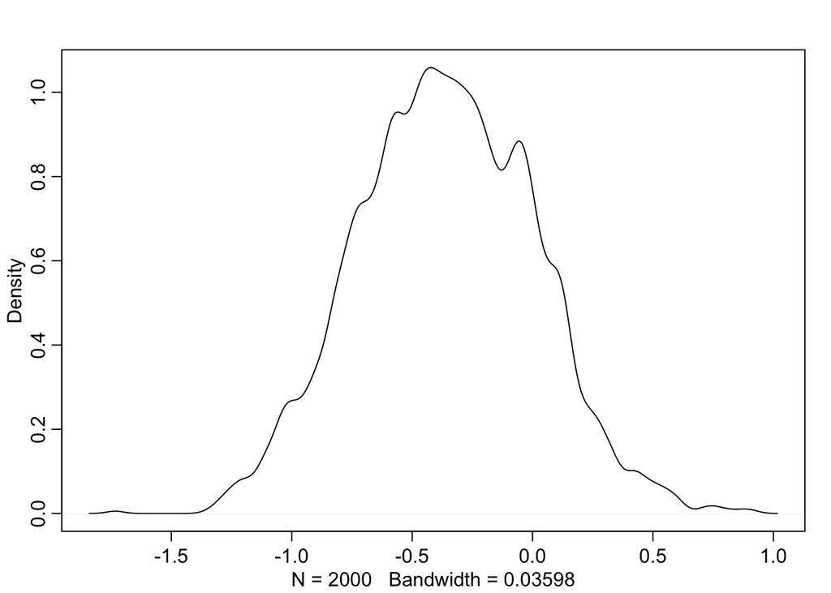

```r
dens(post$a[,5])
```

```r
# all samples for actor 5
```

### step 2: build our own link function

```r
p_link  <- function(treatment, actor = 1, block_id = 1){
  logodds <-with(post,
                 a[ ,actor] + g[ ,block_id] + b[ ,treatment])
  return( inv_logit(logodds))
}
```

### step 3: compute predictions

```r
p_raw <- sapply(1:4, function(i) p_link(i, actor = 2, block_id = 1))
p_mu <- apply(p_raw, 2, mean)
p_ci <- apply(p_raw, 2, PI)
```

## posterior prediction for new clusters

- there is no unique procedure for generalizing predictions outside the sample
- let’s imagine we leave out one actor and try to predict it from the other 6 -> how can we assess the model’s accuracy for predicting actor number 7’s behavior? We can’t use any of the parameter estimates, because those only apply to other individuals. but we can make good use of the `a_bar` and `sigma_a` pparameters. these parameters describe a statistical populatoin of actors, and we can simulate new actors from it.

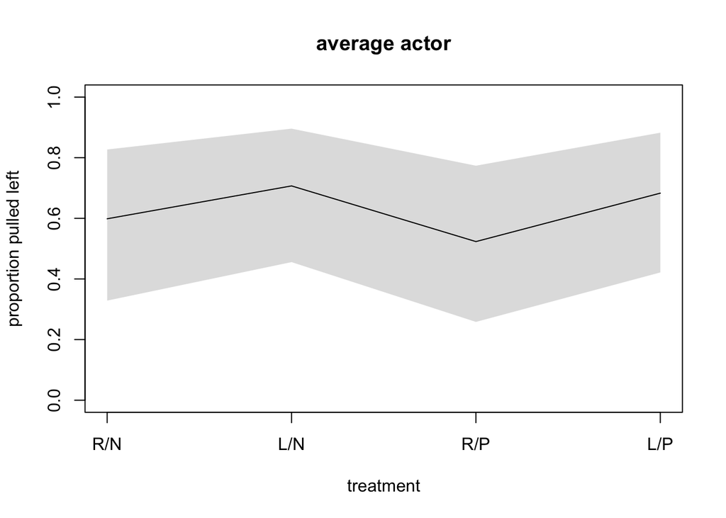

```r
# step one: create link function
# notice we ignore block
    # we are predicting to new blocks
    # so the effect should be about 0
p_link_abar <- function(treatment) {
  logodds <- with(post, a_bar + b[,treatment])
return( inv_logit(logodds))
}


# step two: extract samples and summarize
set.seed(013123)
post <- extract.samples(m13.4)
p_raw <- sapply(1:4, function(i) p_link_abar (i))
p_mu <- apply(p_raw, 2, mean)
p_ci <- apply(p_raw, 2, PI)


# step three: plot

plot( NULL, xlab = "treatment", ylab = "proportion pulled left", main = "average actor",
ylim = c(0,1), xaxt = "n", xlim = c(1,4))
axis( 1, at = 1:4, labels = c("R/N","L/N","R/P","L/P"))
lines(1:4, p_mu)
shade( p_ci,1:4)
```

- grey region is the 89% compatibility interval for an actor with an average intercept.

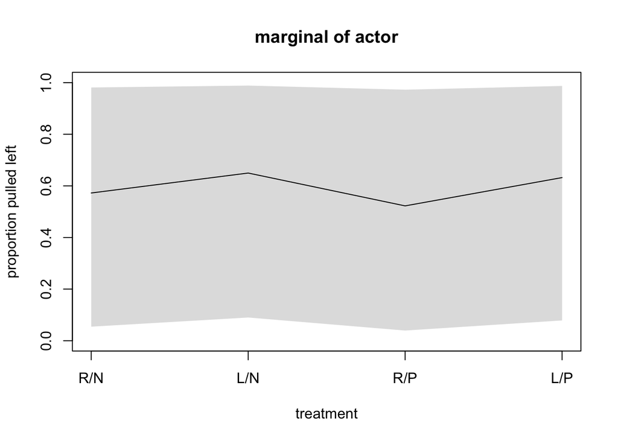

```r
# show variation among actors, need sigma_a

# step one: create link function
a_sim <- with(post, rnorm(length(post$a_bar), a_bar, sigma_a))
p_link_asim <-function(treatment) {
  logodds <-with(post,a_sim + b[ ,treatment])
  return( inv_logit(logodds))
}

# step two : extract samples
  # (using same extraction from above
  # so making code a comment)
      # post <- extract.samples(m13.4)
p_raw_asim <-sapply(1:4, function(i) p_link_asim(i))
p_mu_asim <- apply(p_raw_asim, 2, mean)
p_ci_asim <- apply(p_raw_asim, 2, PI)


# step three: plot
plot( NULL, xlab = "treatment", ylab = "proportion pulled left", main = "marginal of actor", ylim = c(0,1), xaxt = "n", xlim = c(1,4))
axis( 1, at = 1:4, labels = c("R/N","L/N","R/P","L/P"))
lines(1:4, p_mu_asim)
shade( p_ci_asim, 1:4)
```

- when do I use which (average actors vs. marginal of actor)?
  - the predictions for an average actor help to visualize the impact of treatment
  - the predictions that are marginal of actor illustrate how variable different chimpanzees are, acccording to the model

making a plot that displayes both the treatment effect and the variation

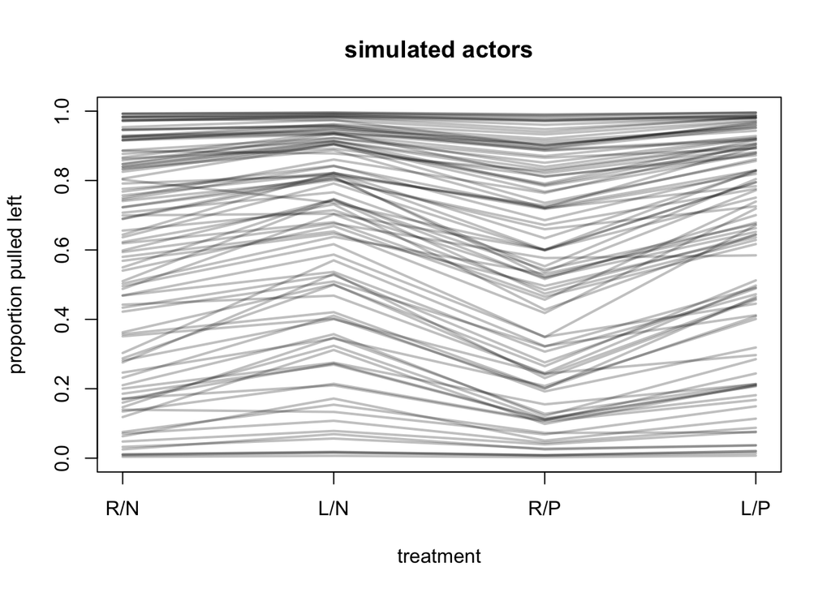

```r
# use the code from above, up until "p_raw_asim"
plot( NULL, xlab = "treatment", ylab = "proportion pulled left",
      main = "simulated actors", ylim = c(0,1) ,xaxt = "n", xlim = c(1,4))
axis(1,at = 1:4, labels = c("R/N","L/N","R/P","L/P"))
for (i in 1:100) lines(1:4, p_raw_asim[i,], col = grau(0.25), lwd = 2)
```

## post-stratification: **how can we use a non-representative sample of a population to generate representative predictions for the same population?**

```
- the idea is to fit a model in which each demographic slice of the population has its own outcome.\
- then the estimates of the outcomes are re-weighted using general census information about the full population (related to the outcome)\
```